# Sea surface temperature measured by satellite

Julie Faucher, Laurent Dubroca, Claudia Schlagenhauf

## Sea surface temperature

- Summary: Satellite measurements show how the sea temperature changed over time
- Main competence: Practice a scientific way of working
- Time: 45 min
- Vocabulary: temperature, satellite
- Experiment: yes
- Equipment: jar, infrared thermometer
- Objective: Understand how a satellite can measure the temperature of the ocean. Become aware of the evolution of the sea temperature over time and in a certain area.

## Documents

Print the following student worksheet)

## Study the sea temperature with satellites

European satellites are constantly measuring the sea temperature. We imitated what they do.

## Experiment:

Task: Note down the temperature measured underneath each jar

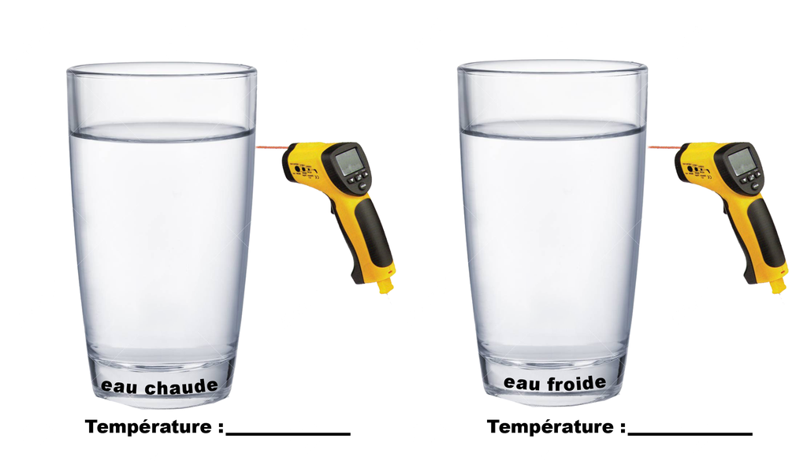

## Satellite

Here is the satellite called MODIS that measures ocean temperature from space.

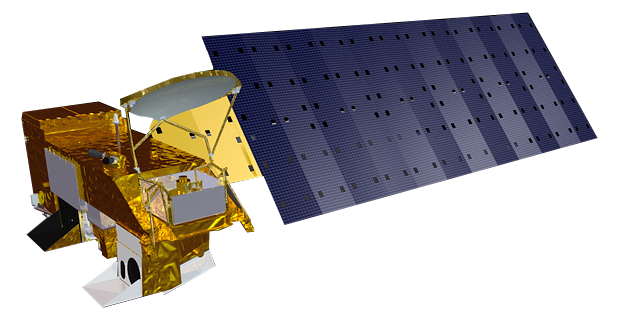

## Map of the sea surface temperature of the study area

Name of the study area : ______________________

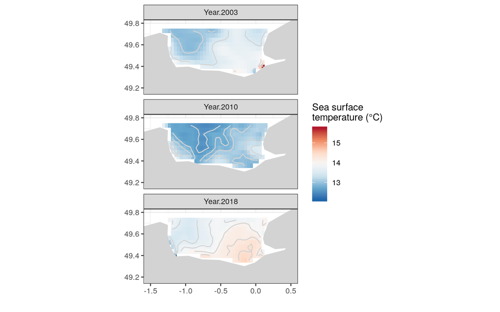

## Plot of the temporal evolution of the annual sea surface temperature

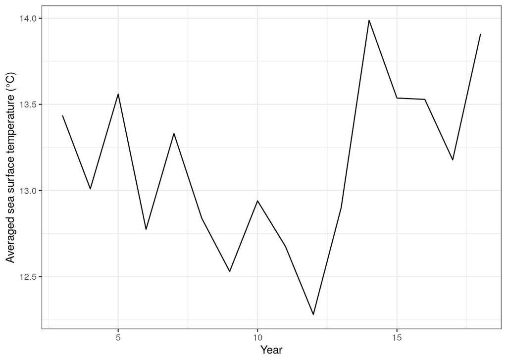

## Conclusion

Describe the temperature changes you see on the maps and the evolution of the average temperature of the area:

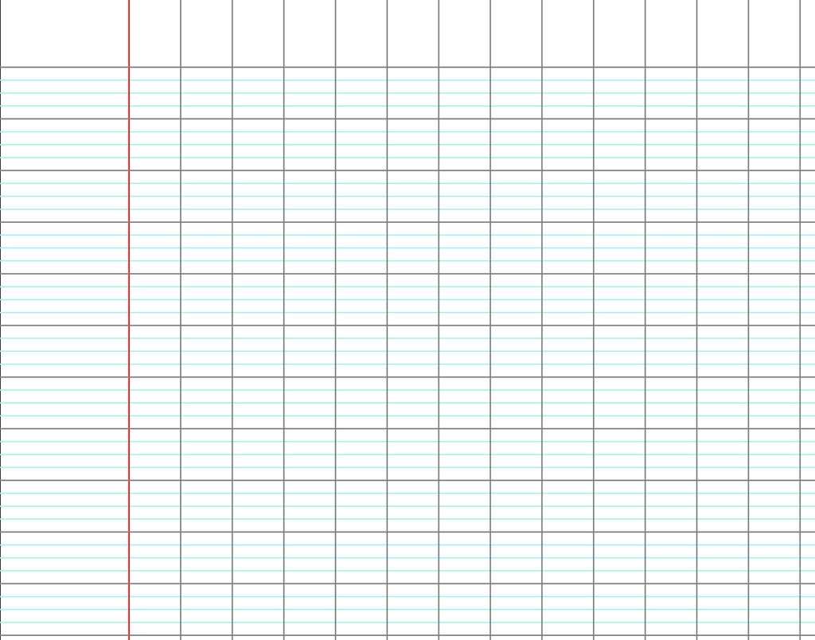